# ME613 - Análise de Regressão

## Intervalo de confiança simultâneo

## Inferência simultânea

Suponha que tenhamos interesse tanto em fazer inferência sobre \(\beta_0\) quanto para \(\beta_1\).

Vimos como construir um intervalo de, por exemplo, \(95\%\) de confiança para \(\hat{\beta}_0\) e um intervalo de \(95\%\) de confiança para \(\hat{\beta}_1\).

Mas, se utilizarmos esses intervalos de confiança individuais, não temos \(95\%\) de confiança para \(\beta_0\) e \(\beta_1\) conjuntamente.

Por exemplo, se essas inferências fossem independentes, teríamos \(0.95^2=0.9025\) de confiança.

No caso, já vimos que \(\hat{\beta}_0\) e \(\hat{\beta}_1\) não são independentes, o que dificulta a determinação do verdadeiro nível de confiança.

## Intervalo de confiança conjunto de Bonferroni

Relembrando:

1. Intervalo de confiança \(100\times(1-\alpha)\%\) para \(\beta_0\): \[\hat{\beta}_0\pm t_{n-2,\alpha/2}\sqrt{\widehat{Var}(\hat{\beta}_0)}\]
2. Intervalo de confiança \(100\times(1-\alpha)\%\) para \(\beta_1\): \[\hat{\beta}_1\pm t_{n-2,\alpha/2}\sqrt{\widehat{Var}(\hat{\beta}_1)}\]

## Intervalo de confiança conjunto de Bonferroni

Seja \(A_1\) o evento de que o intervalo 1 não contenha \(\beta_0\). \(P(A_1)=\alpha\).

Seja \(A_2\) o evento de que o intervalo 2 não contenha \(\beta_1\). \(P(A_2)=\alpha\).

Qual a probabilidade de que ambos intervalos estejam corretos, isto é, \(P(A_1^c\cap A_2^c)\)?

\[P(A_1^c\cap A_2^c)=1-P(A_1\cup A_2)=1-P(A_1)-P(A_2)+P(A_1\cap A_2)\]

Desigualdade de Bonferroni:

\[\begin{eqnarray} P(A_1^c\cap A_2^c)&\geq& 1-P(A_1)-P(A_2)\\ &\geq& 1-2\alpha \end{eqnarray}\]

## Intervalo de confiança conjunto de Bonferroni

Para obter \(100\times(1-\alpha)\%\) de confiança para \(\beta_0\) e \(\beta_1\) conjuntamente, segundo o procedimento de Bonferroni:

1. \[\hat{\beta}_0\pm t_{n-2,\alpha/4}\sqrt{\widehat{Var}(\hat{\beta}_0)}\]
2. \[\hat{\beta}_1\pm t_{n-2,\alpha/4}\sqrt{\widehat{Var}(\hat{\beta}_1)}\]

De maneira que:

\[\begin{eqnarray} P(A_1^c\cap A_2^c)&\geq& 1-P(A_1)-P(A_2)\\ &\geq& 1-\alpha/2-\alpha/2\\ &\geq& 1-\alpha \end{eqnarray}\]

## Notação Matricial para Regressão

## Vetores e Matrizes Aleatórios

Suponha que tenhamos um vetor aleatório \(\mathbf{Y}\) em que \(n=3\):

\[\mathbf{Y}_{3\times1}=\left( \begin{array}{c} Y_1\\ Y_2\\ Y_3 \end{array} \right) \]

\(E(\mathbf{Y})\) é definida como:

\[E(\mathbf{Y})_{3\times1}=\left( \begin{array}{c} E(Y_1)\\ E(Y_2)\\ E(Y_3) \end{array} \right) \]

Se \(\mathbf{Y}\) é uma matriz aleatória de dimensão \(n\times p\):

\[E(\mathbf{Y})_{n\times p}=[E(Y_{ij})]\quad i=1,\ldots,n\,; j=1\ldots, p\]

## Matriz de Variância-Covariância de um Vetor Aleatório

Suponha que tenhamos um vetor aleatório \(\mathbf{Y}\) em que \(n=3\):

\[\mathbf{Y}_{3\times1}=\left( \begin{array}{c} Y_1\\ Y_2\\ Y_3 \end{array} \right) \]

A matriz de variância-covariância de \(\mathbf{Y}\) é definida como:

\[Var(\mathbf{Y})_{3\times3}=\left( \begin{array}{ccc} Var(Y_1) & Cov(Y_1,Y_2) & Cov(Y_1,Y_3)\\ Cov(Y_2,Y_1) & Var(Y_2) & Cov(Y_2,Y_3)\\ Cov(Y_3,Y_1) & Cov(Y_3,Y_2) & Var(Y_3) \end{array} \right) \]

## Matriz de variância-vovariância de um vetor aleatório

Em geral:

\[Var(\mathbf{Y})=E[(\mathbf{Y}-E(\mathbf{Y}))(\mathbf{Y}-E(\mathbf{Y}))^T]\]

\[Var(\mathbf{Y})_{n\times n}=\left( \begin{array}{cccc} Var(Y_1) & Cov(Y_1,Y_2) & \ldots & Cov(Y_1,Y_n)\\ Cov(Y_2,Y_1) & Var(Y_2) & \ldots & Cov(Y_2,Y_n)\\ \vdots & \vdots & & \vdots\\ Cov(Y_n,Y_1) & Cov(Y_n,Y_2) & \ldots & Var(Y_n) \end{array} \right) \]

## Propriedades básicas

Seja \(\mathbf{W}\) um vetor aleatório obtido pela multiplicação do vetor aleatório \(\mathbf{Y}\) e da matriz de constantes \(\mathbf{A}\):

\[\mathbf{W}=\mathbf{A}\mathbf{Y}\,.\]

Temos as seguintes propriedades:

\[E(\mathbf{A})=\mathbf{A}\]

\[E(\mathbf{W})=E(\mathbf{A}\mathbf{Y})=\mathbf{A}E(\mathbf{Y})\]

\[Var(\mathbf{Y})=Var(\mathbf{A}\mathbf{Y})=\mathbf{A}Var(\mathbf{Y})\mathbf{A}^T\]

## Distribuição Normal Multivariada

\[\mathbf{Y}_{p\times1}=\left( \begin{array}{c} Y_1\\ Y_2\\ \vdots\\ Y_p \end{array} \right) \]

\[\boldsymbol\mu_{p\times 1}=E(\mathbf{Y})_{p\times 1}=\left( \begin{array}{c} \mu_1\\ \mu_2\\ \vdots\\ \mu_p \end{array} \right)=\left( \begin{array}{c} E(Y_1)\\ E(Y_2)\\ \vdots\\ E(Y_p) \end{array} \right) \]

## Distribuição Normal Multivariada

\[\boldsymbol\Sigma_{p\times p}=\left( \begin{array}{cccc} Var(Y_1) & Cov(Y_1,Y_2) & \ldots & Cov(Y_1,Y_p)\\ Cov(Y_2,Y_1) & Var(Y_2) & \ldots & Cov(Y_2,Y_p)\\ \vdots & \vdots & & \vdots\\ Cov(Y_p,Y_1) & Cov(Y_n,Y_2) & \ldots & Var(Y_p) \end{array} \right)\]

Função de densidade da normal \(p\)-variada:

\[f(\mathbf{Y})=\frac{1}{(2\pi)^{p/2}|\boldsymbol\Sigma|^{1/2}}\exp\left[-\frac{1}{2}(\mathbf{Y}-\boldsymbol\mu)^T \boldsymbol\Sigma^{-1} (\mathbf{Y}-\boldsymbol\mu)\right]\]

## Regressão Linear Simples com notação matricial

\[Y_i=\beta_0+\beta_1X_i+\varepsilon_i\,,\quad\varepsilon_i\overset{iid}{\sim}\mathbf{N}(0,\sigma^2)\,,\quad i=1,2,\ldots,n\]

\[\mathbf{Y}_{n\times1}=\mathbf{X}_{n\times2}\boldsymbol\beta_{2\times1}+\boldsymbol\varepsilon_{n\times1}\,,\quad \boldsymbol\varepsilon\sim\mathcal{N}(\mathbf{0},\sigma^2\mathbf{I})\]

\[\mathbf{Y}_{n\times1}=\left( \begin{array}{c} Y_1\\ Y_2\\ \vdots\\ Y_n \end{array} \right) \]

\[\mathbf{X}_{n\times 2}=\left( \begin{array}{c} 1 & X_1\\ 1 & X_2\\ \vdots\\ 1 & X_n \end{array} \right)\quad \boldsymbol\beta_{2\times1}=\binom{\beta_0}{\beta_1}\quad \boldsymbol\varepsilon_{n\times1}=\left( \begin{array}{c} \varepsilon_1\\ \varepsilon_2\\ \vdots\\ \varepsilon_n \end{array} \right) \]

## Regressão Linear Simples com notação matricial

\[E(\boldsymbol\varepsilon)_{n\times1}=\mathbf{0}_{n\times1}\]

\[Var(\boldsymbol\varepsilon)_{n\times n}=\sigma^2\mathbf{I}_{n\times n}\]

\[E(\mathbf{Y})=E(\mathbf{X}\boldsymbol\beta+\boldsymbol\varepsilon)=\mathbf{X}\boldsymbol\beta\]

\[Var(\mathbf{Y})=\sigma^2\mathbf{I}\]

## Mínimos Quadrados

Queremos encontrar \(\hat{\boldsymbol\beta}\) que minimiza:

\[\begin{eqnarray} S(\boldsymbol\beta)&=&\sum_{i=1}^n\varepsilon_i^2=\boldsymbol\varepsilon^T\boldsymbol\varepsilon=(\mathbf{Y}-\mathbf{X}\boldsymbol\beta)^T(\mathbf{Y}-\mathbf{X}\boldsymbol\beta)\\ &=& \mathbf{Y}^T\mathbf{Y}-\mathbf{Y}^T\mathbf{X}\boldsymbol\beta-\boldsymbol\beta^T\mathbf{X}^T\mathbf{Y}+\boldsymbol\beta^T\mathbf{X}^T\mathbf{X}\boldsymbol\beta\\ &=& \mathbf{Y}^T\mathbf{Y}-2\boldsymbol\beta^T\mathbf{X}^T\mathbf{Y}+\boldsymbol\beta^T\mathbf{X}^T\mathbf{X}\boldsymbol\beta \end{eqnarray}\]

\[\begin{eqnarray} \frac{\partial S(\boldsymbol\beta)}{\partial\boldsymbol\beta} = -2\mathbf{X}^T\mathbf{Y}+2\mathbf{X}^T\mathbf{X}\boldsymbol\beta \end{eqnarray}\]

Equação normal: \(\mathbf{X}^T\mathbf{X}\hat{\boldsymbol\beta}=\mathbf{X}^T\mathbf{Y}\)

\[\hat{\boldsymbol\beta}=(\mathbf{X}^T\mathbf{X})^{-1}\mathbf{X}^T\mathbf{Y}\]

## Mínimos Quadrados

\[\begin{eqnarray} Var(\hat{\boldsymbol\beta})&=&Var\left[(\mathbf{X}^T\mathbf{X})^{-1}\mathbf{X}^T\mathbf{Y}\right]\\ &=&(\mathbf{X}^T\mathbf{X})^{-1}\mathbf{X}^TVar(\mathbf{Y})\mathbf{X}(\mathbf{X}^T\mathbf{X})^{-1}\\ &=&(\mathbf{X}^T\mathbf{X})^{-1}\mathbf{X}^T\sigma^2\mathbf{I}\mathbf{X}(\mathbf{X}^T\mathbf{X})^{-1}\\ &=&\sigma^2(\mathbf{X}^T\mathbf{X})^{-1} \end{eqnarray}\]

\(\mathbf{H}\) é a matriz de projeção ortogonal no espaço coluna de \(\mathbf{X}\).

\[\hat{\mathbf{Y}}=\mathbf{X}\hat{\boldsymbol\beta}=\underbrace{\mathbf{X}(\mathbf{X}^T\mathbf{X})^{-1}\mathbf{X}^T}_{\mathbf{H}}\mathbf{Y}\]

\[\mathbf{e}=\mathbf{Y}-\hat{\mathbf{Y}}=\mathbf{Y}-\mathbf{H}\mathbf{Y}=(\mathbf{I}-\mathbf{H})\mathbf{Y}\]

## Interpretação geométrica

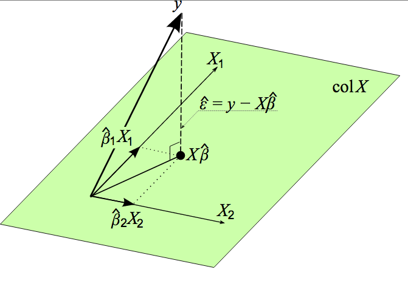

## Interpretação geométrica

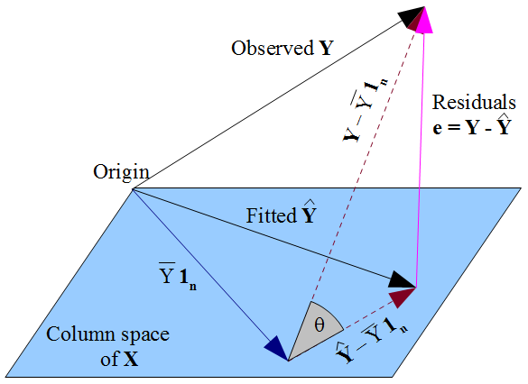

## Interpretação geométrica

\[\sum_{i=1}^n(Y_i-\bar{Y})^2=\sum_{i=1}^n(\hat{Y}_i-\bar{Y})^2+\sum_{i=1}^n(Y_i-\hat{Y}_i)^2\]

Pitágoras:

\[ ||\mathbf{Y}-\bar{Y}\mathbf{1}_n||^2 = ||\mathbf{Y}-\hat{\mathbf{Y}}||^2+||\hat{\mathbf{Y}}-\bar{Y}\mathbf{1}_n||^2\]

\[R^2=1- \frac{SQE}{SQT}=1-\frac{||\mathbf{Y}-\hat{\mathbf{Y}}||^2}{||\mathbf{Y}-\bar{Y}\mathbf{1}_n||^2}=\frac{SQReg}{SQT}=\frac{||\hat{\mathbf{Y}}-\bar{Y}\mathbf{1}_n||^2}{||\mathbf{Y}-\bar{Y}\mathbf{1}_n||^2}\]

\[R=\cos(\theta)=\frac{||\hat{\mathbf{Y}}-\bar{Y}\mathbf{1}_n||}{||\mathbf{Y}-\bar{Y}\mathbf{1}_n||}\]

## Exercício

\(X\): temperatura (\(^{\circ} F\)).

\(Y\): semanas até a deterioração do sabor.

```
##    x    y
## 1  8  7.8
## 2  4  9.0
## 3  0 10.2
## 4 -4 11.0
## 5 -8 11.7
```

Utilizando a notação matricial para o modelo de regressão, obtenha:

- \(\mathbf{Y}^T\mathbf{Y}\), \(\mathbf{X}^T\mathbf{X}\) e \(\mathbf{X}^T\mathbf{Y}\), \((\mathbf{X}^T\mathbf{X})^{-1}\).
- \(\hat{\boldsymbol\beta}\)
- vetor de resíduos
- matriz de variância-covariância estimada para \(\hat{\boldsymbol\beta}\).

## ANOVA

\[ \underbrace{\sum_{i=1}^n(Y_i-\bar{Y})^2}_{SQT}=\underbrace{\sum_{i=1}^n(\hat{Y}_i-\bar{Y})^2}_{SQReg} +\underbrace{\sum_{i=1}^n(Y_i-\hat{Y}_i)^2}_{SQE}\]

\[SQT=\sum_{i=1}^n(Y_i-\bar{Y})^2=\sum_{i=1}^nY_i^2-\frac{(\sum_{i=1}^nY_i)^2}{n}\]

\[SQT=\mathbf{Y}^T\mathbf{Y}-\frac{1}{n}\mathbf{Y}^T\mathbf{1}\mathbf{1}^T\mathbf{Y}=\mathbf{Y}^T\left[ \mathbf{I}-\frac{1}{n}\mathbf{1}\mathbf{1}^T \right]\mathbf{Y}\]

## ANOVA

\[\begin{eqnarray} SQE&=&\mathbf{e}^T\mathbf{e}=(\mathbf{Y}-\hat{\mathbf{Y}})^T(\mathbf{Y}-\hat{\mathbf{Y}})\\ &=&(\mathbf{Y}-\mathbf{HY})^T(\mathbf{Y}-\mathbf{HY})\\ &=&\mathbf{Y}^T\mathbf{Y}-\mathbf{Y}^T\mathbf{H}\mathbf{Y}-\mathbf{Y}^T\mathbf{H}^T\mathbf{Y}+\mathbf{Y}^T\mathbf{H}^T\mathbf{H}\mathbf{Y}\\ &=& \mathbf{Y}^T\mathbf{Y}-\mathbf{Y}^T\mathbf{H}\mathbf{Y}\\ &=&\mathbf{Y}^T(\mathbf{I}-\mathbf{H})\mathbf{Y} \end{eqnarray}\]

Obs: \(\mathbf{H}^T=\mathbf{H}\) e \(\mathbf{H}^T\mathbf{H}=\mathbf{H}\)

## ANOVA

\[SQReg=\sum_{i=1}^n(\hat{Y}_i-\bar{Y})^2=\sum_{i=1}^n\hat{Y}_i^2-\frac{(\sum_{i=1}^nY_i)^2}{n}\]

\[\begin{eqnarray} SQReg&=&(\mathbf{HY})^T\mathbf{HY}-\frac{1}{n}\mathbf{Y}^T\mathbf{1}\mathbf{1}^T\mathbf{Y}\\ &=&\mathbf{Y}^T\mathbf{H}\mathbf{Y}-\frac{1}{n}\mathbf{Y}^T\mathbf{1}\mathbf{1}^T\mathbf{Y}\\ &=&\mathbf{Y}^T\left[ \mathbf{H}-\frac{1}{n}\mathbf{1}\mathbf{1}^T \right]\mathbf{Y} \end{eqnarray}\]

## Agradecimento

- Slides criados por Samara F Kiihl / IMECC / UNICAMP

## Leitura

- Applied Linear Statistical Models: 4.1-4.3, Capítulo 5.
- Draper & Smith - [Applied Regression Analysis](http://onlinelibrary.wiley.com/book/10.1002/9781118625590): Capítulos 4, 5 e 20.
- Faraway - [Linear Models with R](http://www.maths.bath.ac.uk/~jjf23/LMR/): Capítulo 2.
- [The Matrix Cookbook](https://www.math.uwaterloo.ca/~hwolkowi/matrixcookbook.pdf)

[figure not shown]

https://xkcd.com/882/